# Workflow Example

## Principal Component Analysis (PCA)

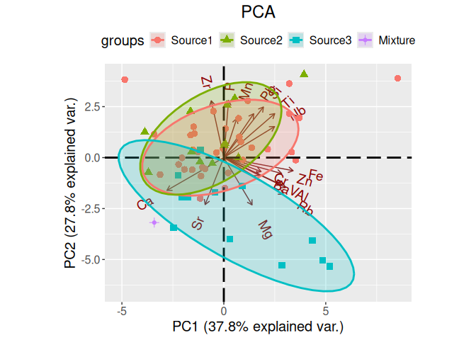

```r
PCA_plot(data)
```

## Individual tracer analysis and ternary diagrams

The individual tracer analysis can be explored visually with ternary diagrams.

This step is especially useful for cases with three sources.

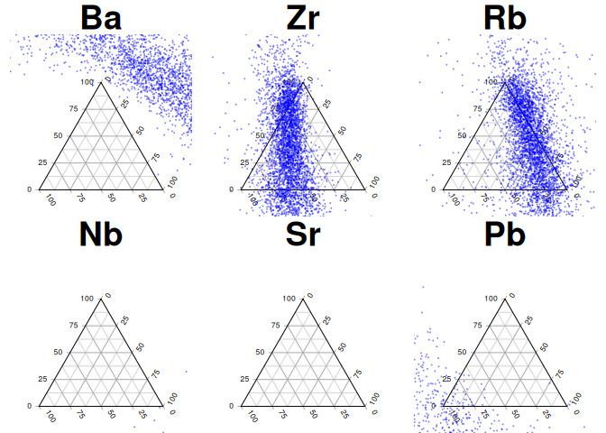

```r
ternary_diagram(data)
```

If the number of tracers is large, the output may span multiple pages. To see additional pages include this argument in the funtion.

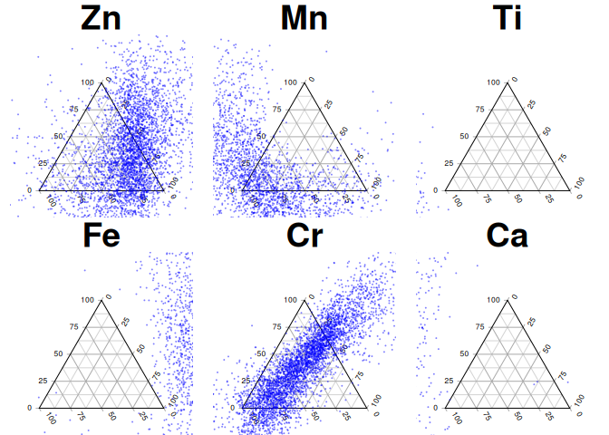

```r
ternary_diagram(data, page = 2)
```

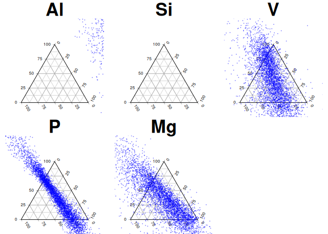

```r
ternary_diagram(data, page = 3)
```

## Range test

The range test identifies tracers whose mixture values fall outside the range defined by the sources.

```r
range_test(data)
```

# 3. Tracer selection

Tracer selection is a key step in `fingerPro`. The process combines pre-screening, tracer ranking, and the exploration of consistent tracer combinations using the CTS method

## CTS_explore

The CTS workflow starts by exploring all possible minimal tracer combinations using the funtion `CTS_explore`:

```r
tracers_seeds <- CTS_explore(data, iter = 1000)
```

Preview: Minimal tracer combinations

| seed_id | tracers | w1 | w2 | w3 | percent_physical | sd_w1 | sd_w2 | sd_w3 | max_sd_wi |
| --- | --- | --- | --- | --- | --- | --- | --- | --- | --- |
| 1 | Cr P | 0.4352013 | 0.2851417 | 0.2796570 | 99.4 | 0.0820186 | 0.0877820 | 0.0395752 | 0.0877820 |
| 2 | Cr Mg | 0.3957113 | 0.2746657 | 0.3296230 | 96.5 | 0.1166657 | 0.0952257 | 0.1137979 | 0.1166657 |
| 3 | Cr V | 0.4085380 | 0.2780684 | 0.3133936 | 93.0 | 0.1670452 | 0.0885184 | 0.1433845 | 0.1670452 |
| 4 | Zr P | 0.6511841 | 0.0465297 | 0.3022862 | 63.0 | 0.1707133 | 0.1707169 | 0.0413458 | 0.1707169 |
| 5 | Rb Cr | 0.6628971 | 0.3455455 | -0.0084426 | 48.6 | 0.1781801 | 0.0930122 | 0.1407672 | 0.1781801 |
| 6 | Zr Cr | 0.2836381 | 0.2449346 | 0.4714274 | 85.2 | 0.2042065 | 0.0938298 | 0.1817926 | 0.2042065 |

The user must select one of these combinations (select a seed) to extent into a final tracer subset using the function `CTS_select`: Select a seed based on the following criteria:

- A high percentage of physically feasible solutions (i.e. 0 < wi < 1)
- Low dispersion across sources (i.e. low variability in the estimated contributions)

Combinations with low dispersion indicate a higher discriminant capacity of the selected tracers.

In practice, the user inspects the output table and selects one row (seed) that provides a good balance between feasibility and low dispersion. This selected seed is then used as input in the `CTS_select` function.

In this example, the first ranked combination (row 1) is selected as the seed.

## CTS_select

```r
selected_data <- CTS_select(data, tracers_seeds, seed_id = 1, error_threshold = 0.05)
```

Preview: dataset after CTS_select

| ID | samples | Cr | P | Mg | V |
| --- | --- | --- | --- | --- | --- |
| 1 | Source1 | 90.34 | 1104.07 | 3944.15 | 56.67 |
| 2 | Source1 | 78.39 | 1064.15 | 3992.01 | 59.63 |
| 3 | Source1 | 61.64 | 1314.66 | 3840.61 | 42.11 |
| 4 | Source1 | 80.32 | 1116.09 | 3507.03 | 61.27 |
| 5 | Source1 | 66.40 | 1111.35 | 3545.03 | 41.31 |
| 6 | Source1 | 69.44 | 1286.99 | 3834.79 | 69.14 |

At this stage, `selected_data` contains the tracer subset that will be used in the unmixing model.

# 4. Unmixing and Visualize the results

The selected tracer subset can now be used to estimate source apportionments.

A quick run can be obtained with the default settings:

```r
output_unmix <- unmix(selected_data)
```

Preview: unmixing results

| ID | Source1 | Source2 | Source3 | GOF |
| --- | --- | --- | --- | --- |
| Mixture (60) | 0.3923894 | 0.2849740 | 0.3226366 | 0.9806114 |
| Mixture (60) | 0.4212065 | 0.2826654 | 0.2961281 | 0.9785353 |
| Mixture (60) | 0.4212065 | 0.2826654 | 0.2961281 | 0.9785353 |
| Mixture (60) | 0.4848043 | 0.2830437 | 0.2321519 | 0.9726158 |
| Mixture (60) | 0.3570352 | 0.3287364 | 0.3142284 | 0.9809761 |
| Mixture (60) | 0.5087059 | 0.2138281 | 0.2774660 | 0.9748148 |

Advanced analyses can be performed by adjusting arguments such as `iter`, `variability`, `lvp`, `constrained`, and `resolution`. These options allow the user to tailor the model settings to the characteristics of the dataset.

For a full description of the available arguments, consult the function documentation:

```r
help("unmix")
```

The source apportionment results can be displayed using density plots or violin plots.

## Density plots

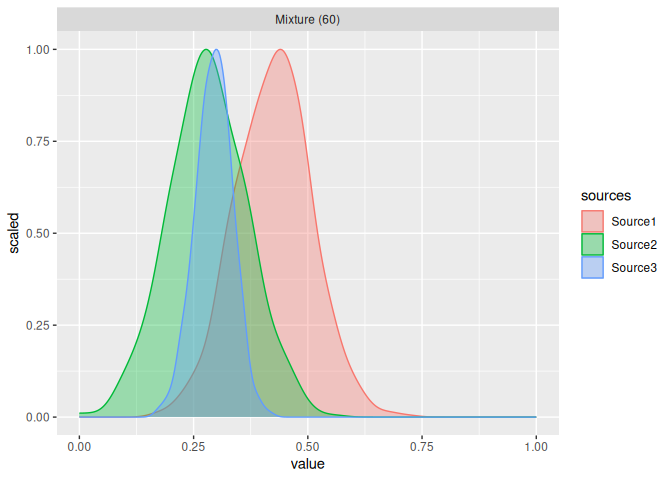

```r
plot_results(output_unmix, violin = FALSE, )
```

## Violin plots

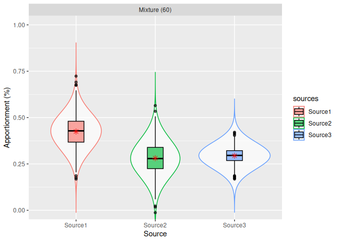

```r
plot_results(output_unmix, violin = TRUE,)
```

These plots help visualize the distribution of source contributions and the variability in the model results.

# 5. Validate the results

Finally, the apportionment solution can be checked for mathematical consistency.

The `validate_results` function allows the user to assess the mathematical consistency of a given set of source apportionments. The apportionments can come from the `fingerPro` model or from any other model, and are evaluated against the tracer dataset used for unmixing.

The user must provide:

- The dataset used for tracer selection and unmixing
- The estimated source apportionments

The function computes the normalized error between the observed tracer values in the mixture and the values predicted from the proposed apportionments.

Low normalized error values indicate that the solution is consistent with the selected tracers, whereas high values may suggest inconsistencies or that the proposed apportionment is not supported by the data.

```r
apportionments <- c(0.435, 0.285, 0.280)
normalized_error <- validate_results(selected_data, apportionments)
```

Preview: normalized error values from validate_results

| tracer | normalized_error |
| --- | --- |
| Cr | 0.0000321 |
| P | 0.0002210 |
| Mg | 0.0198135 |
| V | 0.0108719 |

Low normalized error values indicate that the proposed solution is consistent with the selected tracers.

# Final remarks

This workflow should be repeated independently for each mixture, since optimum tracer selection depends on the combined information from the sources and the specific mixture under study.

# .R Script for beginner users

For beginner users who are not familiar with R Markdown, you can copy the code below into an .R script and run it in R or RStudio step by step.

```r
###################################
###### 0. Install and set wd
###################################
install.packages("fingerPro") # one time
setwd("C:/your/file/directory") # your own working directory (wd)


###################################
###### 1. Load and verify the data
###################################
library(fingerPro)
data <- read_database(system.file("extdata", "example_geochemical_3s_raw.csv", package = "fingerPro")) # Input example dataset


###################################
###### 2. Exploratory analysis
###################################


###### Box plots

box_plot(data)

box_plot(data, page = 1) # Visualise a specific page (e.g. page 1)
box_plot(data, page = 2) # Visualise a specific page (e.g. page 2)
box_plot(data, page = 3) # Visualise a specific page (e.g. page 3)
box_plot(data, n_row = 3, n_col = 6,) # Visualise all tracers

# Save results as a PNG image
png("output_boxplot_all.png", width = 30, height = 15, units = "cm", res = 300) # to save .png results
box_plot(data, n_row = 3, n_col = 6,) # Visualise all tracers
dev.off()

# Check 'help' for more information
help("box_plot")


###### Correlation analysis

correlation_plot(data)

correlation_plot(data, columns = c(1:8)) # correlation plot of  n tracers (e.g. 1 to 8)

# Save results as a PNG image
png("output_correlationplot_tracers1-8.png", width = 25, height = 15, units = "cm", res = 300) # to save .png results
correlation_plot(data, columns = c(1:8)) # correlation plot of  n tracers (e.g. 1 to 8)
dev.off()

# Check 'help' for more information
help("correlation_plot")


###### Linear Discriminant Analysis (LDA)

LDA_plot(data)

# Save results as a PNG image
png("output_LDA.png", width = 15, height = 12, units = "cm", res = 300) # to save .png results
LDA_plot(data)
dev.off()


###### Principal Component Analysis (PCA)

PCA_plot(data)

# Save results as a PNG image
png("output_PCA.png", width = 15, height = 12, units = "cm", res = 300) # to save .png results
PCA_plot(data)
dev.off()


###### Individual tracer analysis and ternary diagrams

output_ternary <- ternary_diagram(data)

ternary_diagram(data, page = 1) # Visualise a specific page (e.g. page 1)
ternary_diagram(data, page = 2) # Visualise a specific page (e.g. page 2)
ternary_diagram(data, page = 3) # Visualise a specific page (e.g. page 3)
ternary_diagram(data, rows = 4, cols = 5)  # Visualise all tracers

# e.g. Save ternary_diagram results as a PNG image
png("output_ternary_all.png", width = 18, height = 12, units = "cm", res = 300) # to save .png results
output_ternary_all <- ternary_diagram(data, rows = 4, cols = 5)  # Visualise all tracers
dev.off()

# Check 'help' for more information
help("ternary_diagram")


###### Range test
data_rangetest <- range_test(data)
write.csv(data_rangetest, "output_rangetest.csv")


###################################
###### 3. Tracer selection
###################################


###### CTS_explore

tracers_seeds <- CTS_explore(data, iter = 1000)
write.csv(tracers_seeds, "output_CTS_explore_tracers_seeds.csv")

# Check 'help' for more information
help("CTS_explore")


###### CTS_select

selected_data <- CTS_select(data, tracers_seeds, seed_id = 1, error_threshold = 0.05) # (e.g. Seed 1 selected with an error of 5% (0.05))
write.csv(selected_data, "output_CTS_select_selected_data.csv")

# Check 'help' for more information
help("CTS_select")

###################################
###### 4. Unmix
###################################

output_unmix <- unmix(selected_data)
write.csv(output_unmix, "output_unmix.csv")

# Check 'help' for more information
help("unmix")

plot_results(output_unmix, violin = FALSE) # Density plot
plot_results(output_unmix, violin = TRUE) # Violing plot

# save density plot
png("output_unmix_densityplot.png", width = 18, height = 12, units = "cm", res = 300) # to save .png results
plot_results(output_unmix, violin = FALSE) # Density plot
dev.off()

# save violin plot
png("output_unmix_violinplot.png", width = 18, height = 12, units = "cm", res = 300) # to save .png results
plot_results(output_unmix, violin = TRUE) # Violing plot
dev.off()


###################################
###### 5. Validate results
###################################

apportionments <- c(0.435, 0.285, 0.280)
normalized_error <- validate_results(selected_data, apportionments = c(0.435, 0.285, 0.280), error_threshold = 0.05)
write.csv(normalized_error, "output_validate_results_normalized_error.csv")

# Check 'help' for more information
help("validate_results")
```